# KAGGLE MACHINE LEARNING NOTEBOOK

##### *Proceduce guide to solve kaggle competiton*

## 0. Preface

1. **Understand the problem**. We'll look at each variable and do a philosophical analysis about their meaning and importance for this problem.
2. **Univariable study**. We'll just focus on the dependent variable ('SalePrice') and try to know a little bit more about it.
3. **Multivariate study**. We'll try to understand how the dependent variable and independent variables relate.
4. **Basic cleaning**. We'll clean the dataset and handle the missing data, outliers and categorical variables.
5. **Test assumptions**. We'll check if our data meets the assumptions required by most multivariate techniques.

### Summary

[1]. **Exploratory data analysis** .

[1.1] General

- ProfileReport()
- info()
- value_count()
- describe()
- hist()

[1.2] EDA

- Visualize output:

  ```
  .plot()
  ```

- Correllation:

  ```
    .corr()
    .scatter_matrix()
  ```

[1.3] Attribute Combinations

[2] **Data Cleaning**

[2.1] Numerical variables

[2.1.1] Missing data

- Analyzing
- dropna()
- drop()
- fillna()
- SimpleImputer()

[2.1.2] Outliers

[2.1.3] Contaminated data

[2.1.4] Invalid data

[2.1.5] Duplicate data

- drop_duplicate()

[2.2] Categorical Variables

[2.2.1] Encoder

- OrdinalEncoder()
- OneHotEncoder()

[2.2.2] Inconsistent data

[2.2.3] Datatype issues

[2.4] Feature Scaling

- MinMaxScaler()
- StandardScaler()

To some Internal Section

```python
import pandas as pd
from pandas_profiling import  ProfileReport
import numpy as np

# Load data on github
titanic_path = "https://raw.githubusercontent.com/thanhtam98/Kaggle-machine-learnin-note/main/data/titanic/"
titanic_df_train = pd.read_csv(titanic_path + "train.csv")
housing_path = "https://raw.githubusercontent.com/thanhtam98/Kaggle-machine-learnin-note/main/data/housing/"
housing_df_train = pd.read_csv(housing_path + "train.csv")
```

```python
# Split num and cat
titanic_df_train_num = titanic_df_train.select_dtypes(exclude=["object"])
titanic_df_train_cat = titanic_df_train.select_dtypes(exclude=[np.number])
# print("Titanic numberic \n" + str(titanic_df_train_num.head))
# print("Titanic categorical \n" + str(titanic_df_train_cat.head))

housing_df_train_num = housing_df_train.select_dtypes(exclude=["object"])
housing_df_train_cat = housing_df_train.select_dtypes(exclude=[np.number])
print("Housing numberic  \n" + str(housing_df_train_num.head))
# print("Housing categorical  \n" + str(housing_df_train_cat.head))


# make housing data as main data
df_train = housing_df_train
df_train_num = housing_df_train_num
```

```
Housing numberic
<bound method NDFrame.head of         Id  MSSubClass  LotFrontage  LotArea  OverallQual  OverallCond  \
0        1          60         65.0     8450            7            5
1        2          20         80.0     9600            6            8
2        3          60         68.0    11250            7            5
3        4          70         60.0     9550            7            5
4        5          60         84.0    14260            8            5
...    ...         ...          ...      ...          ...          ...
1455  1456          60         62.0     7917            6            5
1456  1457          20         85.0    13175            6            6
1457  1458          70         66.0     9042            7            9
1458  1459          20         68.0     9717            5            6
1459  1460          20         75.0     9937            5            6

      YearBuilt  YearRemodAdd  MasVnrArea  BsmtFinSF1  ...  WoodDeckSF  \
```

[output cut: 39 more lines]

## 1. Exploratory data analysis

*Phải có cái nhìn tổng quan về giá trị output bên ngoài thực tiễn. Và chúng là người muốn hiểu biết về nó*

### 1.1 General

#### pandas_profiling ProfileReport

```python
import pandas as pd
from pandas_profiling import ProfileReport

titanic_df_train.head()
profile = ProfileReport(
    titanic_df_train, title="Pandas Profiling Report for Housing train dataset"
      )
profile.to_file("pandas_profiling_example.html")
```

#### pandas support function

```
<class 'pandas.core.frame.DataFrame'>
RangeIndex: 8693 entries, 0 to 8692
Data columns (total 14 columns):
 #   Column        Non-Null Count  Dtype
---  ------        --------------  -----
 0   PassengerId   8693 non-null   object
 1   HomePlanet    8492 non-null   object
 2   CryoSleep     8476 non-null   object
 3   Cabin         8494 non-null   object
 4   Destination   8511 non-null   object
 5   Age           8514 non-null   float64
 6   VIP           8490 non-null   object
 7   RoomService   8512 non-null   float64
 8   FoodCourt     8510 non-null   float64
 9   ShoppingMall  8485 non-null   float64
 10  Spa           8510 non-null   float64
 11  VRDeck        8505 non-null   float64
 12  Name          8493 non-null   object
 13  Transported   8693 non-null   bool
dtypes: bool(1), float64(6), object(7)
memory usage: 891.5+ KB
```

[output not shown]

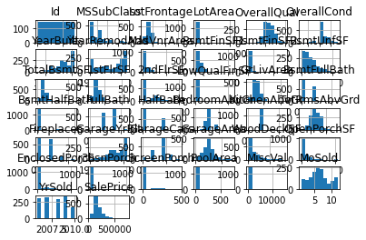

```python
import pandas as pd

titanic_df_train.describe()
titanic_df_train.info()
titanic_df_train.value_counts()
housing_df_train.describe()
housing_df_train.hist()
```

### 1.2 EDA

#### Visualize output

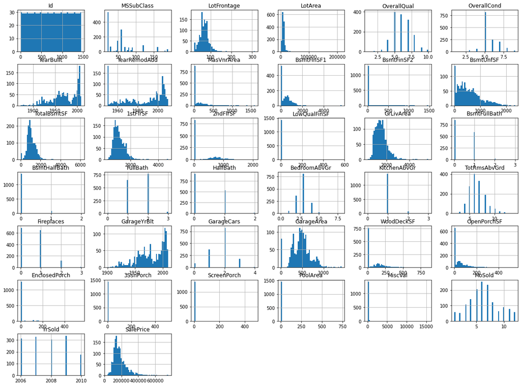

```python
# Matplotlib
%matplotlib inline
from matplotlib import pyplot as plt
import pandas as pd

df_train.head()
df_train.hist(bins=50, figsize=(20, 15));
```

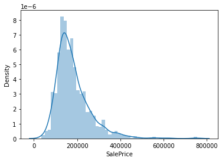

```python
# Seaborn
import seaborn as sns

sns.distplot(df_train['SalePrice']);
```

[output not shown]

[output cut: 19 more lines]

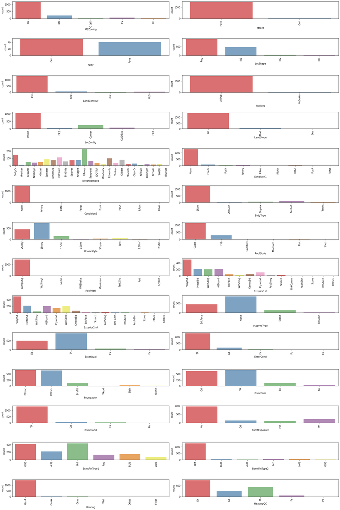

```python
# Counter Plots (for categorical)
fig, axes = plt.subplots(round(len(housing_df_train_cat.columns) / 3), 2, figsize=(20, 30))

for i, ax in enumerate(fig.axes):
    # plot barplot of each feature
    if i < len(housing_df_train_cat.columns) - 1:
        ax.set_xticklabels(ax.xaxis.get_majorticklabels(), rotation=90)
        sns.countplot(x=housing_df_train_cat.columns[i], alpha=0.7, data=housing_df_train_cat, ax=ax, palette = "Set1")

fig.tight_layout()
```

[output not shown]

[output cut: 20 more lines]

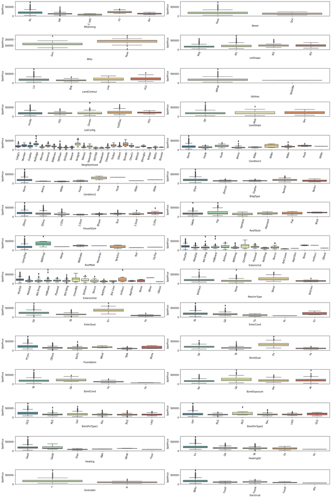

```python
housing_df_train_cat['SalePrice'] = housing_df_train['SalePrice']
fig, axes = plt.subplots(
    round(len(housing_df_train_cat.columns)/3), 2, figsize=(20, 30))

for i, ax in enumerate(fig.axes):
    # plot the variation of SalePrice in each feature
    if i < len(housing_df_train_cat.columns) - 1:
        ax.set_xticklabels(ax.xaxis.get_majorticklabels(), rotation=75)
        sns.boxplot(x=housing_df_train_cat.columns[i], y="SalePrice", data=housing_df_train_cat, ax=ax, palette="Spectral_r")

fig.tight_layout()
```

#### Relationship and Correllation

##### Relationship with numerical variables

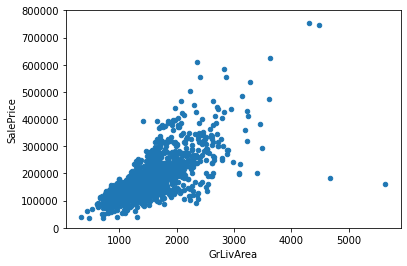

```python
#scatter plot grlivarea/saleprice
var = 'GrLivArea'
data = pd.concat([df_train['SalePrice'], df_train[var]], axis=1)
data.plot.scatter(x=var, y='SalePrice', ylim=(0,800000));
```

##### Relationship with categorical features

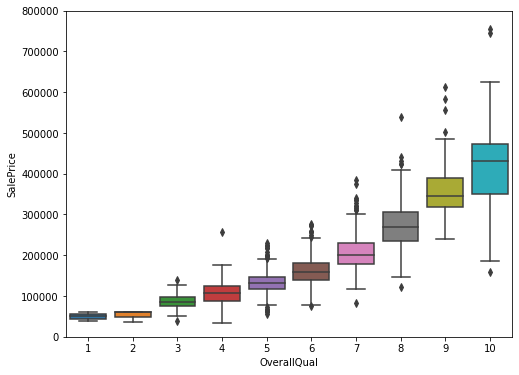

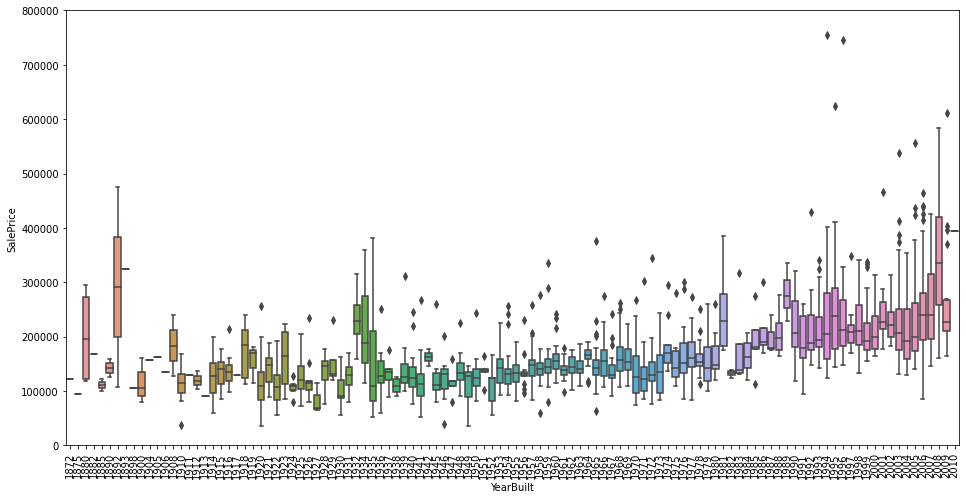

```python
import seaborn as sns

#box plot overallqual/saleprice
var = 'OverallQual'
data = pd.concat([df_train['SalePrice'], df_train[var]], axis=1)
f, ax = plt.subplots(figsize=(8, 6))
fig = sns.boxplot(x=var, y="SalePrice", data=data)
fig.axis(ymin=0, ymax=800000);

var = 'YearBuilt'
data = pd.concat([df_train['SalePrice'], df_train[var]], axis=1)
f, ax = plt.subplots(figsize=(16, 8))
fig = sns.boxplot(x=var, y="SalePrice", data=data)
fig.axis(ymin=0, ymax=800000);
plt.xticks(rotation=90);
```

##### Correlation matrix heat map

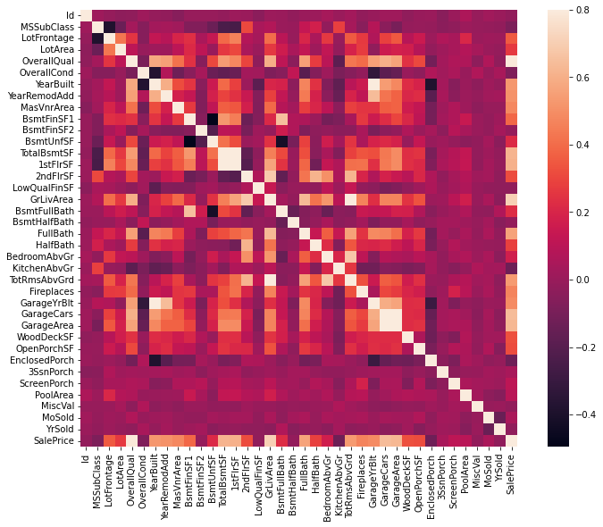

```python
#correlation matrix
corrmat = df_train.corr()
f, ax = plt.subplots(figsize=(12, 9))
sns.heatmap(corrmat, vmax=.8, square=True);

#Todo: detail, discard the lower correlation  variables
```

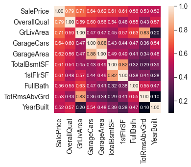

```python
# zoomed heatmap style

k = 10 #number of variables for heatmap
cols = corrmat.nlargest(k, 'SalePrice')['SalePrice'].index
cm = np.corrcoef(df_train[cols].values.T)
sns.set(font_scale=1.25)
hm = sns.heatmap(cm, cbar=True, annot=True, square=True, fmt='.2f', annot_kws={'size': 10}, yticklabels=cols.values, xticklabels=cols.values)
plt.show()
```

##### Scatter plots

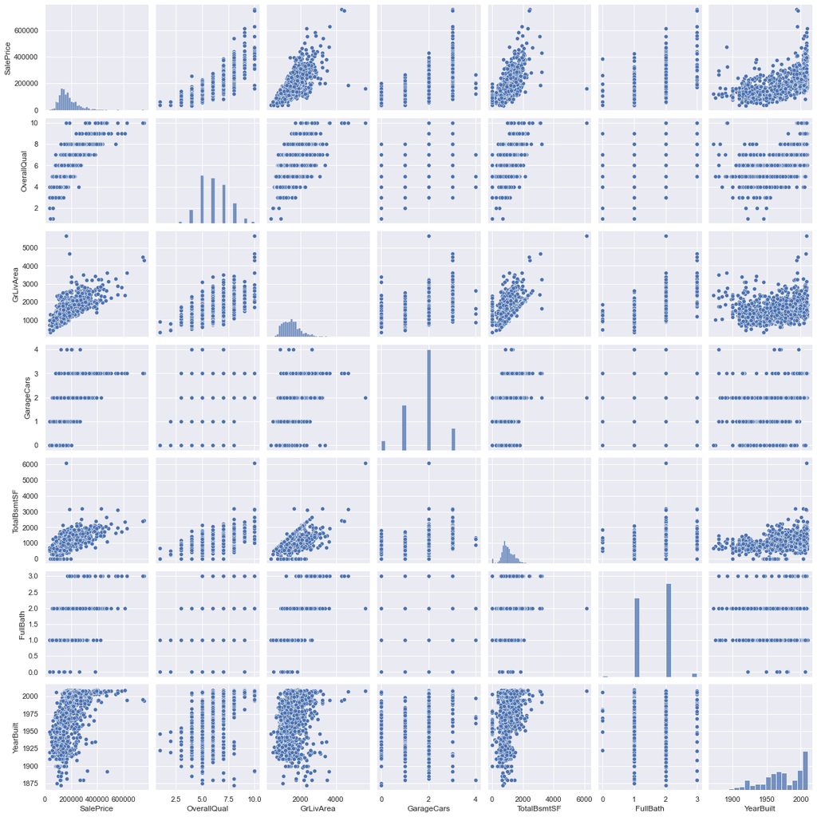

```python
#scatterplot
sns.set()
cols = ['SalePrice', 'OverallQual', 'GrLivArea', 'GarageCars', 'TotalBsmtSF', 'FullBath', 'YearBuilt']
sns.pairplot(df_train[cols], size = 2.5)
plt.show();
```

## 2. Data clearning

### 2.1 Numerical variables

#### 2.1.1 Missing data:

- How prevalent is the missing data?
- Is missing data random or does it have a pattern?

##### Analyzing

```python
# Todo: add more function to analyze data
total = df_train.isnull().sum().sort_values(ascending=False)
percent = (df_train.isnull().sum()/df_train.isnull().count()).sort_values(ascending=False)
missing_data = pd.concat([total, percent], axis=1, keys=['Total', 'Percent'])
missing_data.head(20)
```

|  | Total | Percent |
| --- | --- | --- |
| PoolQC | 1453 | 0.995205 |
| MiscFeature | 1406 | 0.963014 |
| Alley | 1369 | 0.937671 |
| Fence | 1179 | 0.807534 |
| FireplaceQu | 690 | 0.472603 |
| LotFrontage | 259 | 0.177397 |
| GarageYrBlt | 81 | 0.055479 |
| GarageCond | 81 | 0.055479 |
| GarageType | 81 | 0.055479 |
| GarageFinish | 81 | 0.055479 |
| GarageQual | 81 | 0.055479 |
| BsmtFinType2 | 38 | 0.026027 |
| BsmtExposure | 38 | 0.026027 |
| BsmtQual | 37 | 0.025342 |
| BsmtCond | 37 | 0.025342 |
| BsmtFinType1 | 37 | 0.025342 |
| MasVnrArea | 8 | 0.005479 |
| MasVnrType | 8 | 0.005479 |
| Electrical | 1 | 0.000685 |
| Id | 0 | 0.000000 |

##### Dealing with missing data (Missing data handling)

- **Drop**

```python
#dealing with missing data
df_train = df_train.drop((missing_data[missing_data['Total'] > 1]).index,1)
df_train = df_train.drop(df_train.loc[df_train['Electrical'].isnull()].index)
df_train.isnull().sum().max()
```

```
0
```

- **Dropna**

```python
df_train = df_train.dropna()
df_train.isnull().sum()
```

```
Id               0
MSSubClass       0
MSZoning         0
LotArea          0
Street           0
                ..
MoSold           0
YrSold           0
SaleType         0
SaleCondition    0
SalePrice        0
Length: 63, dtype: int64
```

- **Fillna**

```python
df_train = df_train.fillna(0)
```

- Imputation

```python
from re import S
from sklearn.impute import SimpleImputer

my_imputer = SimpleImputer(strategy="most_frequent") # most_frequent, mean, median, constant
df_train_imputed = pd.DataFrame(my_imputer.fit_transform(df_train_num))
df_train_imputed.columns = df_train_num.columns
```

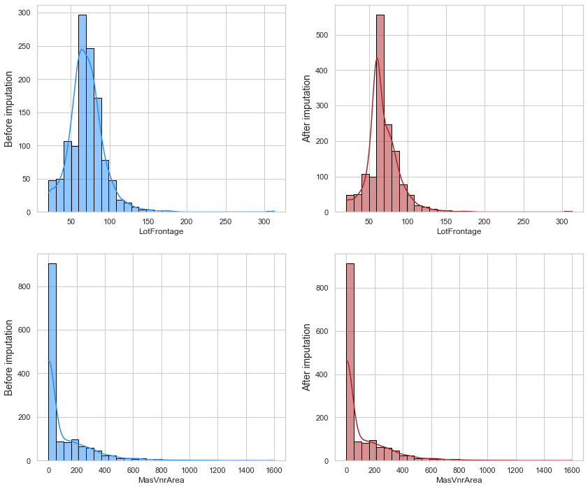

```python
# OPTIONAL: COMPATE BEFORE AND AFTER IMPUTATION

# Define figure parameters
sns.set(rc={"figure.figsize": (14, 12)})
sns.set_style("whitegrid")
fig, axes = plt.subplots(2, 2)

# Plot the results
for feature, fig_pos in zip(["LotFrontage", "MasVnrArea"], [0, 1]):
    """Features distribution before and after imputation"""
    # before imputation
    p = sns.histplot(ax=axes[fig_pos, 0], x=df_train_num[feature],
                     kde=True, bins=30, color="dodgerblue", edgecolor="black")
    p.set_ylabel(f"Before imputation", fontsize=14)
    # after imputation
    q = sns.histplot(ax=axes[fig_pos, 1], x=df_train_imputed[feature],
                     kde=True, bins=30, color="firebrick", edgecolor="black")
    q.set_ylabel(f"After imputation", fontsize=14)
```

#### 2.1.2 Outlier

##### Univariate analysis

- Standardizing data

```python
#standardizing data
from sklearn.preprocessing import StandardScaler
saleprice_scaled = StandardScaler().fit_transform(df_train['SalePrice'][:,np.newaxis]);
low_range = saleprice_scaled[saleprice_scaled[:,0].argsort()][:10]
high_range= saleprice_scaled[saleprice_scaled[:,0].argsort()][-10:]
print('outer range (low) of the distribution:')
print(low_range)
print('\nouter range (high) of the distribution:')
print(high_range)
```

```
outer range (low) of the distribution:
[[-1.83820775]
 [-1.83303414]
 [-1.80044422]
 [-1.78282123]
 [-1.77400974]
 [-1.62295562]
 [-1.6166617 ]
 [-1.58519209]
 [-1.58519209]
 [-1.57269236]]

outer range (high) of the distribution:
[[3.82758058]
 [4.0395221 ]
 [4.49473628]
 [4.70872962]
 [4.728631  ]
 [5.06034585]
 [5.42191907]
 [5.58987866]
 [7.10041987]
 [7.22629831]]
```

##### Bivariate analysis

[output not shown]

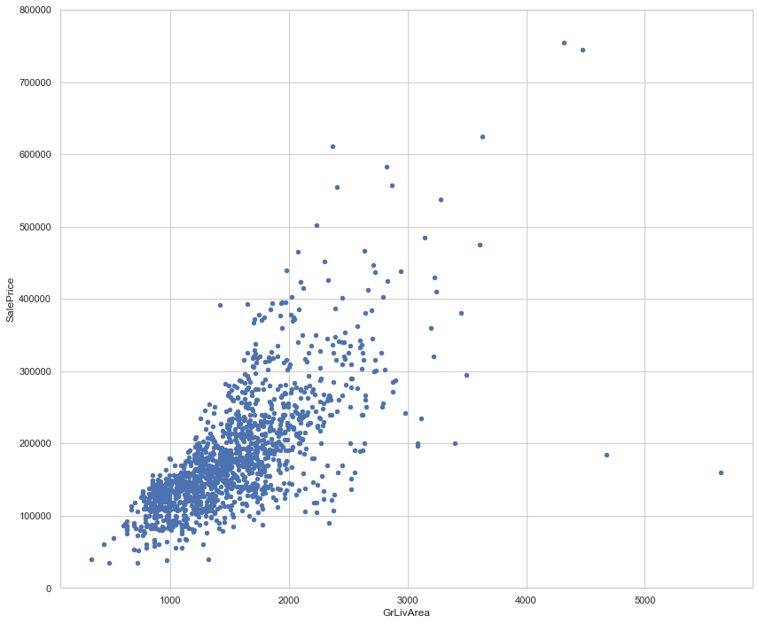

```python
#bivariate analysis saleprice/grlivarea
var = 'GrLivArea'
data = pd.concat([df_train['SalePrice'], df_train[var]], axis=1)
data.plot.scatter(x=var, y='SalePrice', ylim=(0,800000));
```

[output not shown]

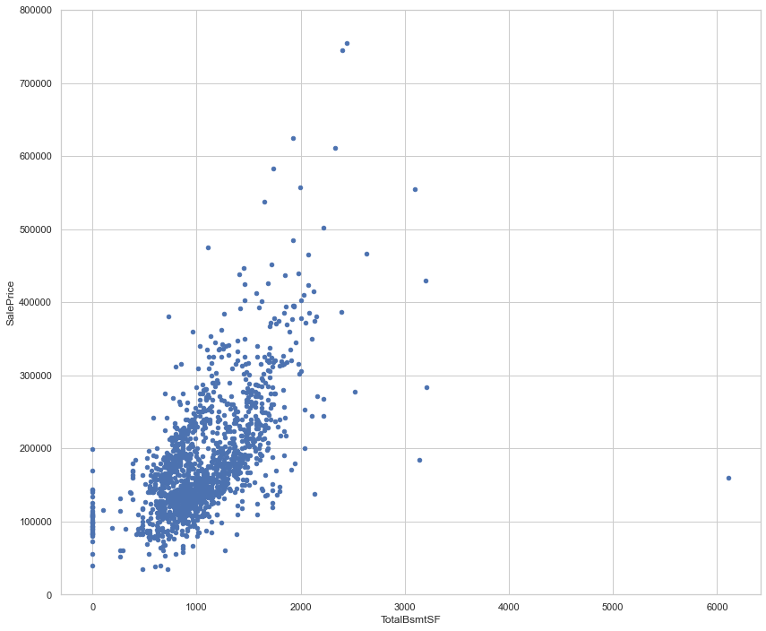

```python
#bivariate analysis saleprice/grlivarea
var = 'TotalBsmtSF'
data = pd.concat([df_train['SalePrice'], df_train[var]], axis=1)
data.plot.scatter(x=var, y='SalePrice', ylim=(0,800000));
```

#### 2.1.3 Contaminated data

#### 2.1.4 Invalid data

#### 2.1.5 Duplicate data

### 2.2 Categorical Variables

#### 2.2.1 Encoder

- **OrdinalEncoder**
- **OneHotEncoder**

#### 2.2.2 Inconsistent data

#### 2.2.3 Datatype issues

### 2.3 Quasi-Constant variables

```python
from sklearn.feature_selection import VarianceThreshold
# 0.05: drop column where 95% of the values are constant
sel = VarianceThreshold(threshold=0.05)
# fit finds the features with constant variance
sel.fit(df_train_num.iloc[:, :-1])
# Get the number of features that are not constant
print(f"Number of retained features: {sum(sel.get_support())}")

print(f"\nNumber of quasi_constant features: {len(df_train_num.iloc[:, :-1].columns) - sum(sel.get_support())}")

quasi_constant_features_list = [x for x in df_train_num.iloc[:, :-1].columns if x not in df_train_num.iloc[:, :-1].columns[sel.get_support()]]

print(f"\nQuasi-constant features to be dropped: {quasi_constant_features_list}")
# Let's drop these columns from df_train_num
df_train_num.drop(quasi_constant_features_list, axis=1, inplace=True)
```

```
Number of retained features: 36

Number of quasi_constant features: 1

Quasi-constant features to be dropped: ['KitchenAbvGr']
```

## 3. Feature transform and scaling

- MinMaxScaler()

```python
from sklearn.preprocessing import MinMaxScaler
data = pd.concat([housing_df_train['YearBuilt'], housing_df_train['YearRemodAdd']], axis=1)
scaler = MinMaxScaler(copy=True)
scaler.fit(data)
new = scaler.transform(data)
new
```

```
array([[0.94927536, 0.88333333],
       [0.75362319, 0.43333333],
       [0.93478261, 0.86666667],
       ...,
       [0.5       , 0.93333333],
       [0.56521739, 0.76666667],
       [0.67391304, 0.25      ]])
```

- StandardScaler()

```python
from sklearn.preprocessing import StandardScaler
data = pd.concat([housing_df_train['YearBuilt'], housing_df_train['YearRemodAdd']], axis=1)
scaler = StandardScaler(copy=True)
scaler.fit(data)
new = scaler.transform(data)
new
```

```
array([[ 1.05099379,  0.87866809],
       [ 0.15673371, -0.42957697],
       [ 0.9847523 ,  0.83021457],
       ...,
       [-1.00249232,  1.02402865],
       [-0.70440562,  0.53949344],
       [-0.20759447, -0.96256569]])
```

## 4. Pipeline

```python
# !jupyter nbconvert --to html note.ipynb
```

```python
# !jupyter nbconvert --to pdf note.ipynb
```